# NLP Analysis of Successful Kickstarter Projects

Cho Laam Yuen

2022-03-30

# Identifying Successful Projects

For this measure for success, I simply counted up the number of successful projects in each category. I found that music, film & video, and publishing were the top 3 categories. However, this method does not account for the total number of projects submitted to each category which could potentially have exaggerated the number of successes in each category if more projects were submitted to some categories compared to others.

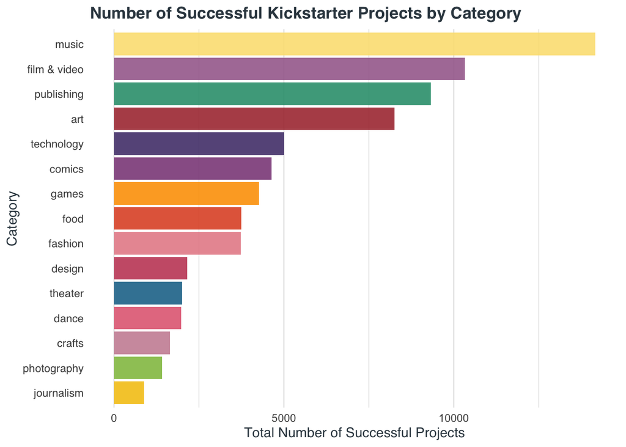

I also tried another measure of success. Here I calculated how quickly the projects took to reach their fundraising goals, which was computed by subtracting the date that the project was launched by the date that the project reached its goal.

[figure not shown]

# Is there a success story formula?

I decided to visualize the most frequently occurring words in the successful projects by counting up the frequency of words appearing in the blurbs.

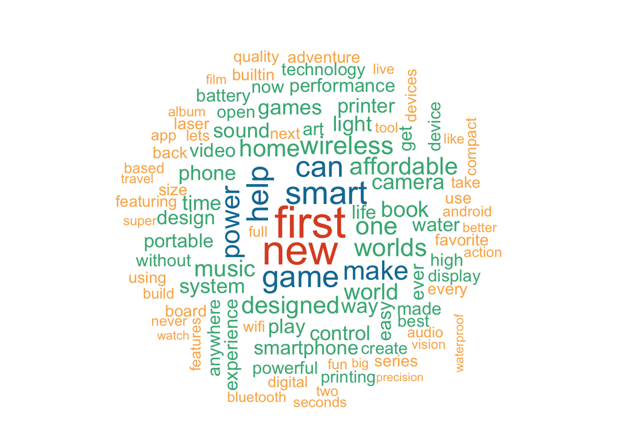

I wanted to compare whether successful and unsuccessful projects differed in the words they used.

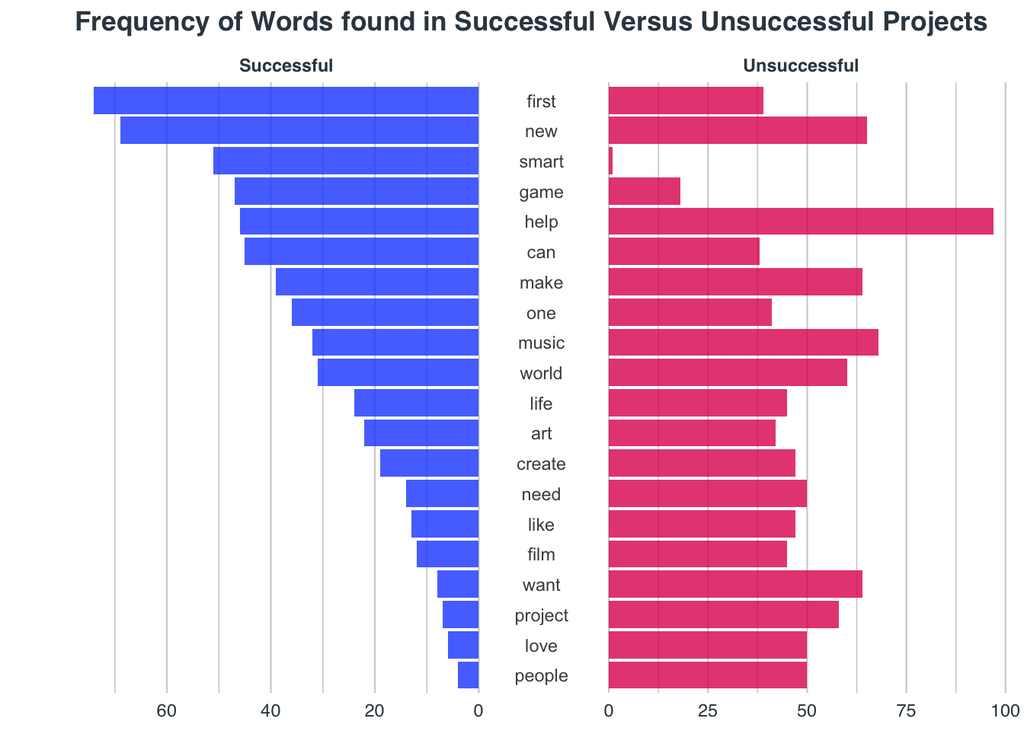

# Short and sweet takes the cake?

I used the Flesh Kincaid metric for readability of the blurbs. There does not appear to be a strong relationship between readability and the amount pledged (my chosen metric for success in this subproblem). Overall, there is a prevailing trend that the blurbs are considered to be quite complex (low Flesh Kincaid scores) by this readability metric. This could be the case because blurbs are a condensed version of a full description which may only include pertinent terms and words that stand out to catch the attention of the reader. As such, the vocabulary used may be more complex, while being limited to 150 characters drives the calculation of the Flesh Kincaid scores down.

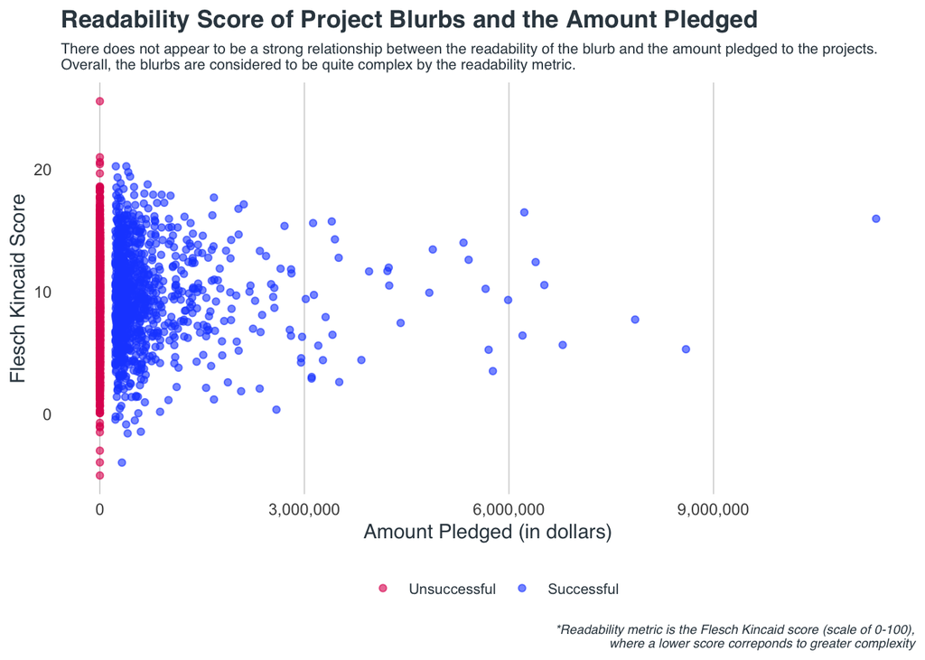

# Sentiment

I used the Hu & Liu dictionary for positive and negative sentiment. The sentiment categories were derived from the sentiment scores, calculated by dividing the difference between number of positive and negative words by total number of positive and negative words within a blurb.

- Very positive sentiment corresponds to scores equal to 1
- Positive sentiment corresponds to scores greater than 0 but less than 1
- Neutral sentiment corresponds to scores equal to 0
- Negative sentiment corresponds to scores less than 0 but greater than -1
- Very negative sentiment corresponds to scores equal to -1

Looking at the visualization, there are almost 2 times the number of unsuccessful compared to successful projects in the very negative sentiment category. In addition, there are also more successful projects in the very positive category, showing a trend that positivity or lack of negativity may indeed attract success.

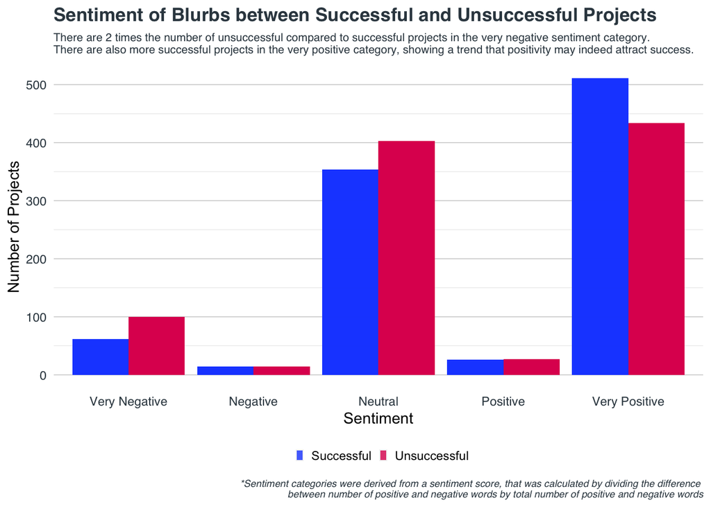

# Positive vs negative words

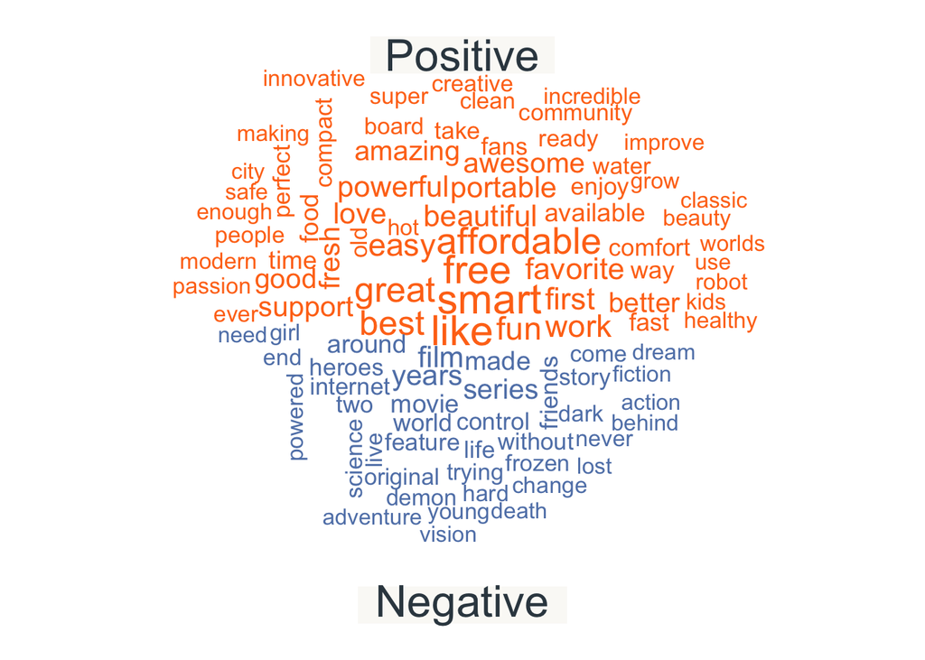

# Does emotion matter?

Emotion categories are derived from the NRC Word-Emotion Association Lexicon. Successful and unsuccessful projects are quite evenly matched on 7 of the 8 emotions expressed. The largest difference between successful and unsuccessful projects are found in the category of joy, where unsuccessful projects were almost 2 times more likely to express joy in their blurb. Subtle differences can also be seen in the categories of sadness, anticipation, and trust where unsuccessful projects were slightly more likely to express those emotions compared to successful projects. In addition, there is almost no difference between the categories of disgust, anger, and fear (very negative emotions) between successful and unsuccessful projects. Overall, it appears that unsuccessful projects were more emotive compared to successful projects. This conclusion is a little surprising in my opinion because emotive language should appeal to the emotions of people who might fund the project. However, too much emotion may be perceived a begging which could explain this surprising finding.

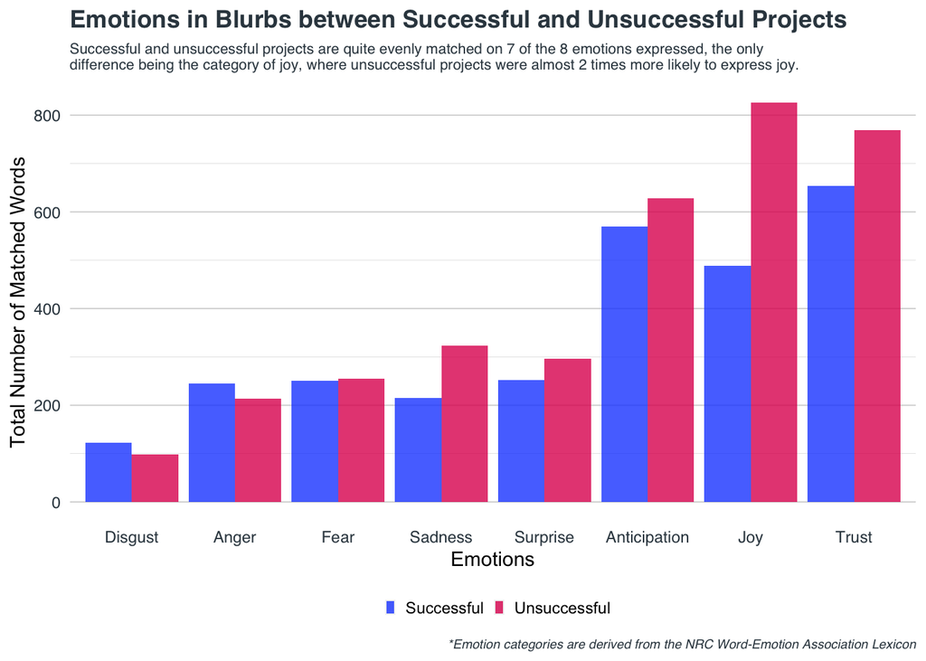